# Exercises

1.What geom would you use to draw a line chart? A boxplot? A histogram? An area chart?

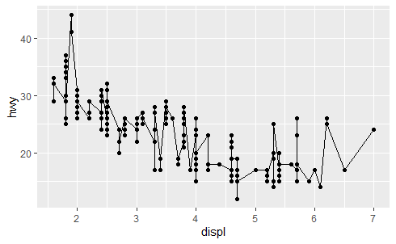

```r
ggplot(data = mpg) +
  geom_line(mapping = aes(x = displ, y = hwy)) +
  geom_point(mapping = aes(x = displ, y = hwy))
```

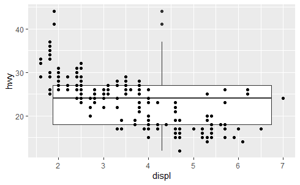

```r
ggplot(data = mpg) +
  geom_boxplot(mapping = aes(x = displ, y = hwy)) +
  geom_point(mapping = aes(x = displ, y = hwy))
```

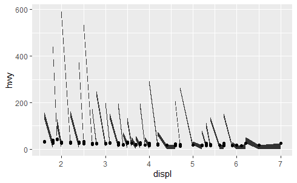

```r
ggplot(data = mpg) +
  geom_area(mapping = aes(x = displ, y = hwy)) +
  geom_point(mapping = aes(x = displ, y = hwy))
```

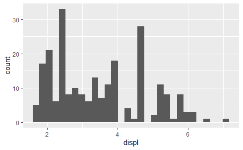

```r
ggplot(data = mpg) +
  geom_histogram(mapping = aes(x = displ))
```

2.Run this code in your head and predict what the output will look like. Then, run the code in R and check your predictions.

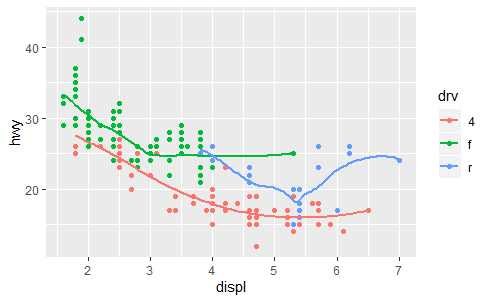

```r
ggplot(data = mpg, mapping = aes(x = displ, y = hwy, color = drv)) +
  geom_point() +
  geom_smooth(se = FALSE)
```

3.What does show.legend = FALSE do? What happens if you remove it? Why do you think I used it earlier in the chapter?

It eliminates the variable legend around the graph. If we remove it the the variable legend will occur.

4. What does the se argument to geom_smooth() do?

It either eliminates or represents the deviation around the chart.

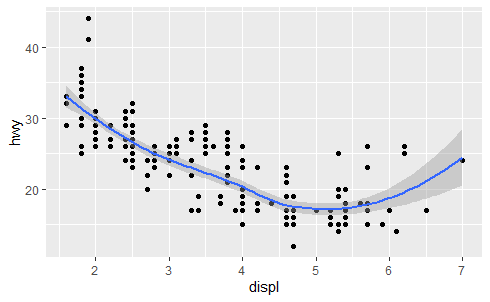

```r
ggplot(data = mpg, mapping = aes(x = displ, y = hwy)) +
  geom_point() +
  geom_smooth()
```

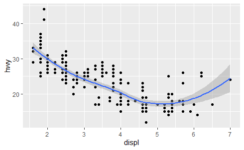

```r
ggplot() +
  geom_point(data = mpg, mapping = aes(x = displ, y = hwy)) +
  geom_smooth(data = mpg, mapping = aes(x = displ, y = hwy))
```

No, because the layers inherit the configuration from ggplot.

```
Ignoring unknown aesthetics: se
```

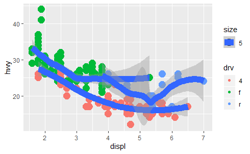

```r
ggplot(data = mpg) + geom_point(mapping = aes(x = displ, y = hwy, color = drv, size = 5)) + geom_smooth(mapping = aes(x = displ, y = hwy, group = drv, size = 5, se = FALSE))
```

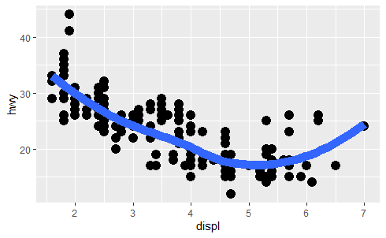

```r
ggplot(data = mpg, mapping = aes(x = displ, y = hwy)) +
  geom_point(size = 4) +
  geom_smooth(size = 4, se = FALSE )
```

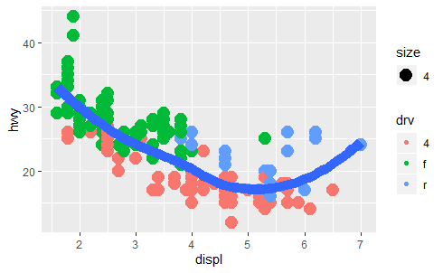

```r
ggplot(data = mpg, mapping = aes(x = displ, y = hwy)) +
  geom_point(mapping = aes(x = displ, y = hwy, color = drv, size = 4)) +
  geom_smooth(size = 4, se = FALSE )
```

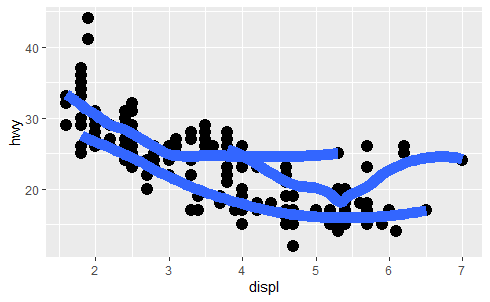

```r
ggplot(data = mpg, mapping = aes(x = displ, y = hwy, group = drv)) +
  geom_point(size = 4) +
  geom_smooth(size = 4, se = FALSE )
```

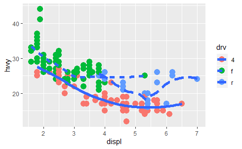

```r
ggplot(data = mpg) +
  geom_point(mapping = aes(x = displ, y = hwy, color = drv), size = 4) +
  geom_smooth(mapping = aes(x = displ, y = hwy, linetype = drv), size = 2, se = FALSE )
```

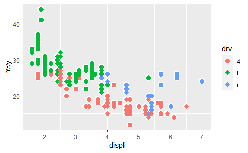

```r
ggplot(data = mpg) +
  geom_point(mapping = aes(x = displ, y = hwy), color = "white", size = 4) + geom_point(mapping = aes(x = displ, y = hwy, color = drv), size = 3)
```

What is the default geom associated with stat_summary()? How could you rewrite the previous plot to use that geom function instead of the stat function?

geom_pointrange,

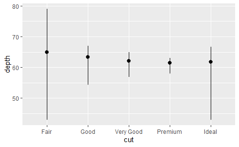

```r
ggplot(data = diamonds) +
  geom_pointrange(mapping = aes(x = cut, y = depth),
                  stat = "summary",
                  fun.ymin = min,
                  fun.ymax = max,
                  fun.y = median)
```

`geom_col` leaves the data as it is. `geom_bar()` creates two variables (count and prop) and then graphs the count data on the y axis.

```r
`?stat_smooth`
```

```
Error: object '?stat_smooth' not found
```

Most geoms and stats come in pairs that are almost always used in concert. Read through the documentation and make a list of all the pairs. What do they have in common?

geom stat area identity ribbon identity bar count col identity bin2d bind2d blank identity boxplot boxplot contour contour count sum crossbar identity errorbar identity errorbarh identity linerange identity pointrange identity curve identity segment identity density density density_2d density2d freqpoly bin histogram bin hex binhex jitter identity label identity path identity line identity map identity point identity polygon identity quantile quantile raster identity rect identity rug identity smooth smooth spoke spoke step identity text identity tile identity violin ydensity

```r
stat_smooth()
```

```
geom_smooth: se = TRUE, na.rm = FALSE
stat_smooth: method = auto, formula = y ~ x, se = TRUE, n = 80, fullrange = FALSE, level = 0.95, na.rm = FALSE, method.args = list(), span = 0.75
position_identity
```

What variables does stat_smooth() compute? What parameters control its behaviour?

`stat_smooth()` computes the y, the predicted value of y for each x value.

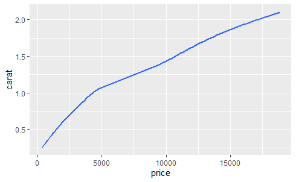

```r
ggplot(data = diamonds, aes(x = price, y = carat)) + stat_smooth()
```

the se of that value predicted, together with the upper and lower bound of that point prediction.

In our proportion bar chart, we need to set group = 1. Why? In other words what is the problem with these two graphs?

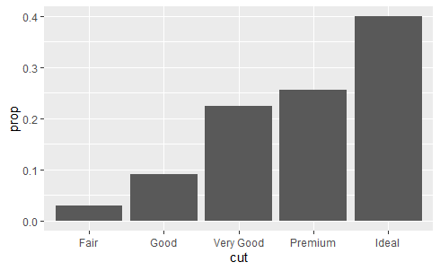

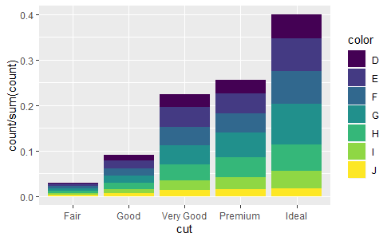

```r
ggplot(data = diamonds) +
  geom_bar(mapping = aes(x = cut, y = ..count.. / sum(..count..), fill = color))
```